# Análisis cluster

April 2024

## Introducción

**Objetivo**

- `Objetivo`: cómo agrupar observaciones estableciendo grupos (o clusters) con las más similares.
- `Aprendizaje supervisado`: en la muestra `se indica a qué grupo pertenece cada observación`.
  - Regresión Logística
  - Análisis Discriminante
- `Aprendizaje no supervisado` (o automático): en este caso `no disponemos de una muestra inicial donde se indique a qué grupo pertenece cada observación`. De hecho, en algunas ocasiones podemos decidir cuántos grupos queremos establecer.
  - Análisis Cluster

**El contexto**

- Dispondremos de `una muestra` (o población) de $n$ individuos (objetos) en los que hemos medido $k$ variables numéricas $(X_1,\dots,X_k)$.
- Sin embargo, en este caso, `no dispondremos de una variable` $Y$ que nos diga a qué grupo (población) pertenece cada observación.
- Incluso, en algunos casos, `no sabremos ni siquiera el número de grupos`.
- De hecho, lo que haremos será determinar los valores de $Y$ que nos asigne los grupos que minimicen una `función costo` adecuada.
- Para ello tendremos que utilizar una función `distancia` que nos mida cómo de similares son dos observaciones (individuos).
- La `elección de esta distancia` es muy importante y la solución final dependerá de la distancia elegida.

## Distancias entre individuos

**La distancia Euclídea**

- La distancia más popular utilizada es la `distancia Euclídea`, definida como
  $$d_E(\mathbf x, \mathbf c)=\sqrt{(\mathbf x-\mathbf c)'(\mathbf x-\mathbf c)}=\sqrt{\sum_{j=1}^k (x_j-c_j)^2}$$
  para todo $\mathbf x, \mathbf c\in \mathbb{R}^k$ (vectores columna).
- En nuestro contexto, habitualmente $\mathbf x=(x_1,\dots,x_k)'$ representará un `individuo` y $\mathbf c=(c_1,\dots,c_k)'$ el `centroide` de un grupo.
- En `R` se puede computar como

```r
dE <- function(x, y) sqrt(sum((x - y)*(x - y)))
```

- Por ejemplo, para $x = (0, 0)'$ e $y = (1, 1)'$:

```r
x <- c(0, 0)
y <- c(1, 1)
dE(x, y)
```

```
[1] 1.414214
```

**La distancia de Mahalanobis**

- Otra opción es la `distancia de Mahalanobis` que usa la métrica de los datos, definida como
  $$d_M(\mathbf x,\mathbf c)=\sqrt{(\mathbf x- \mathbf c)'V^{-1}(\mathbf x- \mathbf c)},$$
  donde $V=Cov(X_1,\dots,X_k)$.
- El principal problema es que `si hay grupos`, esta matriz puede ser `distinta en cada grupo`.
- Incluso, aunque supongamos que todos los grupos tienen la misma matriz de covarianzas, estos tendrán medias distintas y, como desconocemos los grupos, no podemos estimar $V$ (como hacíamos en el Análisis Discriminante).
- Una solución es suponer inicialmete que todos los individuos están en un mismo grupo (población) y calcular (estimar) la media y la covarianza en ella.
- En `R` se puede calcular usando la función `mahalanobis(x, y, V)`, que proporciona el cuadrado de esta distancia, para
  $$V = \left (
  \begin{array}{cc}
  1 & 1/2 \\ 1/2 & 1
  \end{array} \right ),$$
  $x = (0, 0)'$ e $y = (1, 1)'$,

```r
V <- matrix(c(1, 1/2,
              1/2, 1), nrow = 2, ncol = 2, byrow = TRUE)
x <- c(0, 0)
y <- c(1, 1)
mahalanobis(x, y, V)
```

```
[1] 1.333333
```

- O bien, como

```r
dM <- function(x, y, V) sqrt(sum(t(x - y) %*% solve(V) %*% (x - y)))
dM(x, y, V)
```

```
[1] 1.154701
```

```r
## Si hacemos el cuadrado
dM(x, y, V)^2
```

```
[1] 1.333333
```

- Obviamente, si $V=I$ (matriz identidad), se obtiene la `distancia Euclídea` que, por lo tanto, representará a `vv.aa. independientes con varianza uno`.
- En otros casos, la distancia de Mahalanobis tendrá en cuenta las varianzas de las variables y sus covarianzas (correlaciones o dependencia).
- Las circunferencias (`elipsoides`) obtenidas con $d_V(\mathbf x, \boldsymbol \mu,V)=cte.$ coincidirán con los `conjuntos de nivel de la distribución normal multivariante` ${\cal N}_k(\boldsymbol \mu,V)$ cuya función de densidad es
  $$f(\mathbf x)=\frac1{\sqrt{(2\pi)^k|V|}}\exp\left(-\frac 1 2 (\mathbf x- \boldsymbol \mu)'V^{-1}(\mathbf x- \boldsymbol \mu) \right).$$
  - De esta forma, bajo este modelo y si conocemos $V$, el individuo con medidas $\mathbf x$ se asignará al grupo en donde sea más verosímil, es decir, donde $f_i(x)$ sea máxima, siendo $f_i$ la densidad ${\cal N}_k(\boldsymbol \mu_i,V)$ (tal y como hacíamos en AD).
- Ahora el problema es que no sabemos cómo estimar $\boldsymbol \mu_i$ y $V$ y tampoco sabemos si hay una matriz de covarianzas $V$ común.

**Otras distancias interesantes**

- La `distancia absoluta` (Manhattan, de ciudad o geometría del taxista)
  $$d_A(\mathbf x,\mathbf c)=\sum_{j=1}^k |x_j-c_j|$$
  (que usa las cuadrículas como caminos).
- La `distancia` $L_s$
  $$d_s(\mathbf x, \mathbf c)=\left(\sum_{j=1}^k (x_j-c_j)^s\right)^{1/s}$$
  para $s>0$.
- La `distancia de Pearson`
  $$d_P(\mathbf x, \mathbf c)=\sqrt{\sum_{j=1}^k \left(\frac{x_j-c_j}{\sigma_j}\right)^{2}}$$
  donde $\sigma_i$ es la desviación típica de $X_i$, $i = 1, \dots, k$.
  - Este último caso es equivalente a estandarizar los datos usando $Z_i=X_i/\sigma_i$ o $Z_i=(X_i-\mu_i)/\sigma_i$ lo que nos asegura que las variables tendrán magnitudes similares aunque se usen unidades diferentes en ellas (esto no ocurre en la distancia Euclídea).
  - El principal problema es que desconocemos $\sigma_i$ y $\mu_i$ que tendrán que ser estimados usando todos los datos (sin grupos).
  - Obviamente, es equivalente a usar la distancia Euclidea con los datos estandarizados.
  - La distancia no dependerá de las unidades usadas en cada variable (es invariante por cambio de escala).

## Distancias de individuos a grupos y distancias entre grupos

**Distancias de individuos a grupos**

- Además de definir las distancias entre individuos, también tendremos que definir `distancias de individuos a grupos` o `distancias entre grupos`,
  - lo que nos llevará a definir diversas funciones `coste` que determinarán diferentes soluciones finales.
  - Estas vendrán determinadas por el problema que queremos resolver.
- Por ejemplo, si queremos calcular la `distancia de un individuo` $\mathbf x$ `a un grupo` $\{\mathbf z_i: i\in G\}$ formado por $m=|G|$ individuos podemos definir las distancias siguientes:
  $$d_1(\mathbf x,G):=d(\mathbf x, \mathbf C), \quad \mathbf C=\frac 1 {|G|} \sum_{i\in G} \mathbf z_i$$
  $$d_2(\mathbf x,G):=\min_{i\in G} d(\mathbf x, \mathbf z_i),$$

$$d_3(\mathbf x,G):=\max_{i\in G} d(\mathbf x, \mathbf z_i),$$
$$d_4(\mathbf x,G):=\sum_{i\in G} d(\mathbf x,\mathbf z_i),$$
$$d_5(\mathbf x,G):=\sum_{i\in G} d^2(\mathbf x, \mathbf z_i),$$
donde $d$ es una distancia entre individuos.

- Otra opción interesante es calcular (o estimar) una función de densidad para los individuos de un mismo grupo y calcular las distancias como
  $$d(\mathbf x,G_j)=1-\frac{f_j(\mathbf x)}{f_1(\mathbf x)+\dots+f_m(\mathbf x)}.$$

**Distancias entre grupos**

- Análogamente, para las `distancias entre grupos` se pueden usar:
  $$D_1(G_1,G_2)= d(C_1,C_2), \quad C_j=\frac 1 {|G_j|} \sum_{i\in G_j} \mathbf z_i, \quad j=1,2$$
  $$D_2(G_1,G_2)=\min_{i\in G_1,j\in G_2} d(\mathbf z_i, \mathbf z_j),$$
  $$D_3(G_1,G_2)=\max_{i\in G_1,j\in G_2} d(\mathbf z_i, \mathbf z_j),$$
  $$D_4(G_1,G_2)=\frac 1{|G_1||G_2|}\sum_{i\in G_1,j\in G_2} d(\mathbf z_i, \mathbf z_j),$$

$$D_5(G_1,G_2)=\frac 1{|G_1||G_2|}\sum_{i\in G_1,j\in G_2} d^2(\mathbf z_i, \mathbf z_j).$$

- En $d_1$ o en $D_1$ podemos utilizar otros `centroides` $C_1$ y $C_2$ distintos de la media de cada grupo.
- Estas `distancias entre grupos` nos permitirán representar sus distancias y, posteriormente establecer a partir de qué nivel uniremos los grupos formando los gráficos denominados `dendogramas`.
- Finalmente debemos definir una `función costo` que trataremos de minimizar para obtener la solución óptima de ese problema.

**Función costo**

- Supongamos que asignamos los $n$ individuos a un grupo mediante una variable $Y$ que nos indicará con $y_i=j$ que el individuo $i$ se asigna al grupo $j$.
- Podemos definir la `función costo`
  $$\begin{equation}
  J(y)= \sum_j \sum_{i: y_i=j} d(\mathbf x_i,G_j),
  \end{equation}$$
  donde $\displaystyle \sum_{j:y_i=j} 1=1$ para todo $i$ (cada elemento se asigna a un único grupo).
- También `se pueden usar distancias al cuadrado`
  $$\begin{equation}
  J^*(y)= \sum_j \sum_{i: y_i=j} d^2(\mathbf x_i,G_j) .
  \end{equation}$$
- En estos métodos, tenemos que `fijar un número máximo de grupos` ya que si no, la solución óptima será tener $n$ grupos (uno para cada elemento).
- `Otra opción` podría ser `maximizar la suma total de las distancias entre grupos` para la clasificación $y$:
  $$D(y)=\sum_{i<j} D(G_i,G_j).$$
- Todas estas opciones nos llevarán a problemas diferentes que tendrán que resolverse (cuando sea posible) usando sus técnicas específicas (la mayoría de Investigación Operativa).

## Métodos cluster

**Clasificación**

- Estos métodos se pueden dividir en dos grandes grupos:
  - los `métodos jerárquicos`:
    - parten de la idea de juntar las unidades (individuos o grupos) más similares (cercanas).
  - los `métodos no jerárquicos`:
    - establecen un determinado número de grupos y se irá asignando cada individuo al grupo más cercano.
- Solamente veremos un método de cada tipo.

## Método no jerárquico de las K-medias

- El método de las K-medias (`K-means`) es sin duda el método no jerárquico `más popular`.
- Habitualmente usa la distancia Euclídea con los datos sin estandarizar (cuando tienen escalas similares) o estandarizados (distancia de Pearson, cuando tienen escalas diferentes) pero se puede aplicar a otras distancias.
- En este caso tenemos que `fijar un número de grupos predeterminado` $K$ con $1<K\leq n/2$.
- Posteriormente podremos aumentar o disminuir $K$ según la solución obtenida.
- $K$ es el número de grupos.
- $k$ es el número de variables.
- $n$ es el número de observaciones.
- Estos números pueden ser diferentes.

**Algoritmo del método de las K-medias**

- `Paso 0`: Determinar $K$ centroides $C^{0}_1,\dots,C^{0}_K\in \mathbb{R}^k$ al azar.
- `Paso 1`: En la iteración $m$, formar el grupo $G^{m}_j$ con las observaciones que están más cercanas al centroide $C^{m-1}_j$ para $j=1,\dots,K$.
- `Paso 2`: Calcular el centroide $C^{m}_j$ del grupo $G^{m}_j$ definido como el punto que minimiza
  $$\sum_{i\in G^{m}_j} d(\mathbf x_i,C^{m}_j),$$
  o considerando las distancias al cuadrado
  $$\sum_{i\in G^{m}_j} d^2(\mathbf x_i,C^{m}_j),$$
  para $j=1,\dots, K$.
- `Paso 3`: Repetir pasos 1 y 2 hasta que no se produzcan cambios en los grupos del paso 1 o hasta que se haya iterado un número determinado de veces.
- Si usamos la distancia Euclídea y el error cuadrático, los `centroides del paso 2` serán las `medias aritméticas de los datos de cada grupo` ya que si queremos minimizar
  $$\min_{P}
  \sum_{j \in G} d^2(\mathbf O_j , P)$$
  para un grupo $G$, tenemos que
  $$\begin{split}
  \sum_{j \in G} d^2(\mathbf O_j , P) & =
  \sum_{j \in G} (\mathbf O_j − P)^\prime(\mathbf O_j − P) \\
  & =
  \sum_{j \in G}
  (\mathbf O_j − \overline {\mathbf O}_G + \overline {\mathbf O}_G − P)^\prime(\mathbf O_j − \overline {\mathbf O}_G + \overline {\mathbf O}_G − P) \\
  & = |G|(\overline {\mathbf O}_G − P)^\prime(\overline {\mathbf O}_G − P) +
  \sum_{j \in G}
  (\mathbf O_j − \overline {\mathbf O}_G)^\prime(\mathbf O_j − \overline {\mathbf O}_G) \\
  & \quad \quad + 2
  \sum_{j \in G}
  (\overline {\mathbf O}_G − P)^\prime(\mathbf O_j − \overline {\mathbf O}_G)
  \end{split}$$
- (Cont.)

  $$\begin{split}
  \sum_{j \in G} d^2(\mathbf O_j , P) & = |G|(\overline {\mathbf O}_G − P)^\prime(\overline {\mathbf O}_G − P) +
  \sum_{j \in G}
  (\mathbf O_j − \overline {\mathbf O}_G)^\prime(\mathbf O_j − \overline {\mathbf O}_G) \\
  & \quad \quad + 2(\overline {\mathbf O}_G − P)^\prime
  \sum_{j \in G}
  (\mathbf O_j − \overline {\mathbf O}_G) \\
  & = |G|(\overline {\mathbf O}_G − P)^\prime(\overline {\mathbf O}_G − P) +
  \sum_{j \in G}
  (\mathbf O_j − \overline {\mathbf O}_G)^\prime(\mathbf O_j − \overline {\mathbf O}_G),
  \end{split}$$

  donde $\overline {\mathbf O}_G = \displaystyle \frac{1}{|G|} \displaystyle \sum_{j \in G} \mathbf O_j$ es la media del grupo G.
- En la expresión final, el segundo sumando es constante (no depende de $P$) y el mínimo del primer sumando se alcanza con $P = \overline {\mathbf O}_G$ (ya que es la distancia entre esos dos puntos).
- De esta forma el paso 2 es inmediato y en el paso 1 simplemente calculamos las distancias a estos nuevos $K$ centroides (medias) asignando cada individuo al grupo del centroide más cercano (distancia $d_1$).
- El nombre `k-means` proviene de esta propiedad.
- Además, si usamos como función de coste las dadas previamente y hay cambios en los grupos, esta función es estrictamente decrecientes en el paso 1 ya que hay al menos un `objeto` cuya distancia al grupo (centroide) ha disminuido.
- Al recalcular los centroides en el paso 2 las sumas de estas distancias en los grupos disminuirán aún más o se quedarán iguales a las del paso 1.
- Como las `opciones del paso 1` son `finitas` ,
  - este algoritmo conducirá hasta una solución óptima local en un número finito de pasos, que puede ser muy grande.
  - Para `evitar este problema` podemos aplicar el algoritmo varias veces con centroides iniciales diferentes y comparar las soluciones óptimas finales de cada algoritmo.
- Veremos que con unos pocos pasos podemos obtener soluciones muy buenas.

**Un ejemplo sencillo**

- Mostramos con un ejemplo sencillo el funcionamiento del algoritmo.
- Para ello usaremos los datos analizados previamente con regresión logística pero ahora supondremos que no conocemos los grupos de esa muestra.
- Supongamos que tenemos dos variables predictoras $X_1$ y $X_2$ (k = 2) y los datos siguientes:
  $$\scriptsize
  \begin{array}{c|ccc}
  \mbox{Individuo } i & X_1 & X_2 & Y \\ \hline
  1 & 1 & 2 & \\
  2 & 2 & 1 & \\
  3 & 3 & 1 & \\
  4 & 2 & 2 & \\
  5 & 5 & 1 & \\
  6 & 5 & 3 & \\
  7 & 3 & 2 & \\
  8 & 4 & 3 & \\
  9 & 4 & 4 & \\
  10 & 5 & 4 & \\ \hline
  \end{array}$$
- Individuos sin agrupamiento inicial.

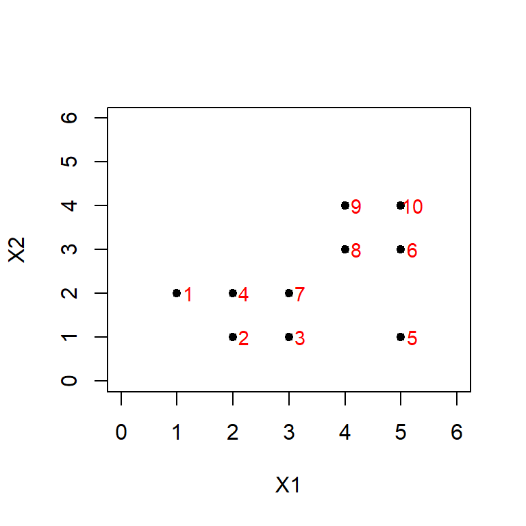

```r
X1 <- c(1, 2, 3, 2, 5, 5, 3, 4, 4, 5)
X2 <- c(2, 1, 1, 2, 1, 3, 2, 3, 4, 4)
plot(X1, X2, xlab = "X1", ylab = "X2", pch = 20,
     xlim = c(0,6), ylim = c(0,6), cex = 1.2)
text(X1 + 0.2, X2, 1:length(X1), cex = 0.9, col = "red")
```

- Observamos que `tienen unidades similares` (por lo que podremos usar la distancia Euclídea) y que parecen formar dos grupos diferentes.
- El `objetivo` es determinar la variable $Y$ que nos asigne cada individuo a un grupo.
- En tabla anterior, hemos dejado en blanco la columna de la variable $Y$ para señalar que en este caso no tenemos una muestra de entrenamiento y, por lo tanto, no podremos saber cuál es la solución óptima (que mejor clasifique a los individuos).
  - `Análisis no supervisado` (o automático).
- Para aplicar el algoritmo con $K=2$ medias (grupos) elegimos dos centroides al azar (dentro de la zona donde están los individuos).
- Para ello usamos la instrucción `runif(2,0,6)` (fijando previamente la semilla con `set.seed`).
- Primer centroide en el paso 0:

```r
set.seed(123124)
C1_0 = runif(2, 0, 6)
C1_0
```

```
[1] 3.101323 1.401716
```

- Segundo centroide en el paso 0:

```r
set.seed(123121)
C2_0 = runif(2, 0, 6)
C2_0
```

```
[1] 2.2950230 0.3726236
```

- Otra opción sería usar dos de esos puntos al azar.
- Con los centroides obtenidos, $C_1^{0}=(3.101323, 1.401716)$ y $C_2^{0}=( 2.2950230, 0.3726236)$, obtenemos las distancias y agrupaciones siguientes:

```r
library("dplyr")
df = data.frame(X1, X2) %>%
  mutate(d_C1 = sqrt((X1 - C1_0[1])^2 + (X2 - C1_0[2])^2),
         d_C2 = sqrt((X1 - C2_0[1])^2 + (X2 - C2_0[2])^2),
         Y = ifelse(d_C1 <  d_C2, 1, 2))
```

$$\scriptsize
\begin{array}{c|cccc|c}
\mbox{Individuo } i & X_1 & X_2 & d(\mathbf X, C_1^0) & d(\mathbf X, C_2^0) & Y \\ \hline
1 & 1 & 2 & 2.1848343 & 2.0797689 & 2 \\
2 & 2 & 1 & 1.1723001 & 0.6932819 & 2 \\
3 & 3 & 1 & 0.4142971 & 0.9437127 & 1 \\
4 & 2 & 2 & 1.2533377 & 1.6539022 & 1 \\
5 & 5 & 1 & 1.9407090 & 2.7767790 & 1 \\
6 & 5 & 3 & 2.4818314 & 3.7709425 & 1 \\
7 & 3 & 2 & 0.6068031 & 1.7735125 & 1 \\
8 & 4 & 3 & 1.8336119 & 3.1321005 & 1 \\
9 & 4 & 4 & 2.7493091 & 4.0080926 & 1 \\
10 & 5 & 4 & 3.2180825 & 4.5249044 & 1 \\
\hline
\end{array}$$

- Cada individuo se asigna al grupo más cercano (midiendo su distancia a cada centroide).
- Individuos agrupados en el primer paso del algoritmo `K-means` con los centroides iniciales (negro).

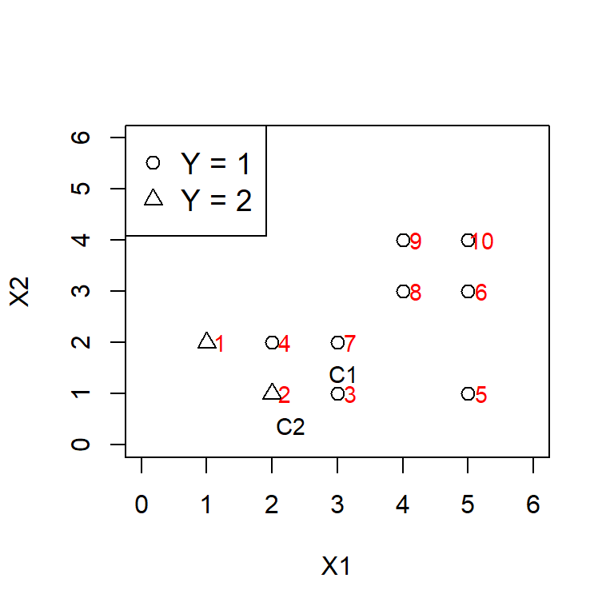

```r
Y <- df$Y
plot(X1, X2, xlab = "X1", ylab = "X2", pch = as.integer(Y),
     xlim = c(0,6), ylim = c(0,6), cex = 1.2)
text(X1 + 0.2, X2, 1:length(X1), cex = 0.9, col = "red")
text(C1_0[1], C1_0[2], "C1", cex = 0.9, col = "black")
text(C2_0[1], C2_0[2], "C2", cex = 0.9, col = "black")
legend('topleft', legend = c('Y = 1','Y = 2'),
       pch = 1:2, cex = 1.2)
```

- En el siguiente paso, calculamos lo nuevos centroides, que son las medias de los individuos de cada grupo.

```r
centroides = df %>%
  group_by(Y) %>%
  summarise(C_x1 = mean(X1),
            C_x2 = mean(X2)) %>%
  ungroup
C1_1 = c(centroides$C_x1[1], centroides$C_x2[1])
C1_1
```

```
[1] 3.875 2.500
```

```r
C2_1=  c(centroides$C_x1[2], centroides$C_x2[2])
C2_1
```

```
[1] 1.5 1.5
```

- Estos centroides son:
  $$\begin{split}
  C_1^{1} & =(3.875, 2.5) \\
  C_2^{1} & =(1.5, 1.5).
  \end{split}$$
- Individuos agrupados en el primer y segundo paso del algoritmo K-means con los centroides iniciales (negro) y los nuevos (rojo).

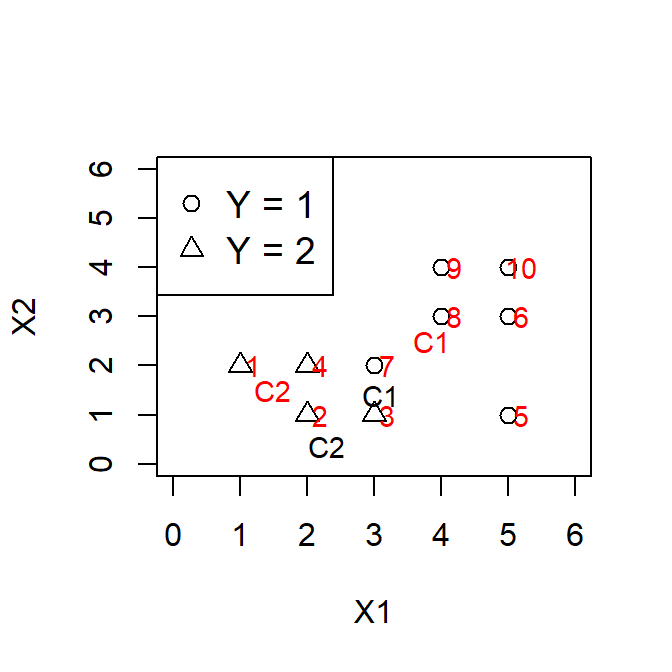

```r
df = df %>%
  mutate(d_C1 = sqrt((X1 - C1_1[1])^2 + (X2 - C1_1[2])^2),
         d_C2 = sqrt((X1 - C2_1[1])^2 + (X2 - C2_1[2])^2),
         Y = ifelse(d_C1 < d_C2,
                    1,
                    2))
Y <- df$Y
plot(X1, X2, xlab = "X1", ylab = "X2", pch = as.integer(Y),
     xlim = c(0,6), ylim = c(0,6), cex = 1.2)
text(X1 + 0.2, X2, 1:length(X1), cex = 0.9, col = "red")
text(C1_0[1], C1_0[2], "C1", cex = 0.9, col = "black")
text(C2_0[1], C2_0[2], "C2", cex = 0.9, col = "black")
text(C1_1[1], C1_1[2], "C1", cex = 0.9, col = "red")
text(C2_1[1], C2_1[2], "C2", cex = 0.9, col = "red")
legend('topleft', legend = c('Y = 1','Y = 2'), pch = 1:2, cex = 1.2)
```

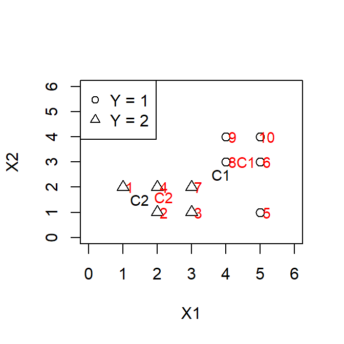

```r
df = df %>%
  mutate(d_C1 = sqrt((X1 - C1_1[1])^2 + (X2 - C1_1[1])^2),
         d_C2 = sqrt((X1 - C2_1[1])^2 + (X2 - C2_1[2])^2),
         Y = ifelse(d_C1 < d_C2,
                    1,
                    2))

centroides = df %>%
  group_by(Y) %>%
  summarise(C_x1 = mean(X1),
            C_x2 = mean(X2))
C1_2 = c(centroides$C_x1[1], centroides$C_x2[1])
C2_2 =  c(centroides$C_x1[2], centroides$C_x2[2])
df = df %>%
  mutate(d_C1 = sqrt((X1 - C1_2[1])^2 + (X2 - C1_2[2])^2),
         d_C2 = sqrt((X1 - C2_2[1])^2 + (X2 - C2_2[2])^2),
         Y = ifelse(d_C1 < d_C2,
                    1,
                    2))
Y <- df$Y
plot(X1, X2, xlab = "X1", ylab = "X2", pch = as.integer(Y),
     xlim = c(0,6), ylim = c(0,6), cex = 1.2)
text(X1 + 0.2, X2, 1:length(X1), cex = 0.9, col = "red")
text(C1_1[1], C1_1[2], "C1", cex = 0.9, col = "black")
text(C2_1[1], C2_1[2], "C2", cex = 0.9, col = "black")
text(C1_2[1], C1_2[2], "C1", cex = 0.9, col = "red")
text(C2_2[1], C2_2[2], "C2", cex = 0.9, col = "red")
legend('topleft', legend = c('Y = 1','Y = 2'), pch = 1:2, cex = 1)
```

- Cuando los grupos no varían en dos iteraciones seguidas los centroides coinciden y el algoritmo se detiene.
- `Problema`: este algoritmo puede depender de los valores iniciales.
- Presentamos la agrupación de los individuos con otros centroides iniciales.
- Centroides iniciales: $C_1^{0}=(2.482099,2.270985)$ y $C_2^{0}=(3.851084, 5.344700)$.
- Centroides finales: $C_1=(2.66667, 1.5)$ y $C_2=(4.5, 3.5)$.

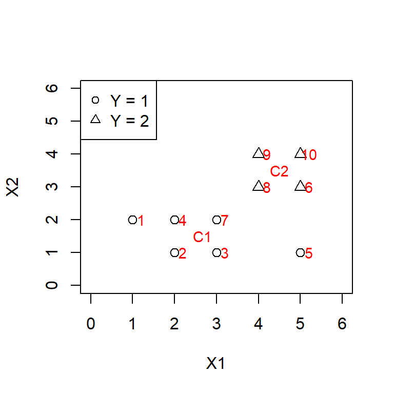

```r
K = 2
## Paso 0
C = matrix(NA, ncol = 2, nrow = K)

C[1, ] = c(2.482099,2.270985)
C[2, ] = c(3.851084, 5.344700)

clusters = matrix(NA, ncol = 2, nrow = nrow(df))
clusters[, 1] = 1
clusters[, 2] = 2

i = 2
while(sum(clusters[, 1] == clusters[, 2]) != nrow(df)) {
## Paso 1
df = df %>%
  mutate(d_C1 = sqrt((X1 - C[1, 1])^2 + (X2 - C[1, 2])^2),
         d_C2 = sqrt((X1 - C[2, 1])^2 + (X2 - C[2, 2])^2),
         Y = ifelse(d_C1 < d_C2,
                    1,
                    2))
clusters[, 1] = df$Y
## Paso 2
centroides = df %>%
  group_by(Y) %>%
  summarise(C_x1 = mean(X1),
            C_x2 = mean(X2))
C[1, ] = c(centroides$C_x1[1], centroides$C_x2[1])
C[2, ] =  c(centroides$C_x1[2], centroides$C_x2[2])
df = df %>%
  mutate(d_C1 = sqrt((X1 - C[1, 1])^2 + (X2 - C[1, 2])^2),
         d_C2 = sqrt((X1 - C[2, 1])^2 + (X2 - C[2, 2])^2),
         Y = ifelse(d_C1 < d_C2,
                    1,
                    2))
clusters[, 2] = df$Y
i = i + 1
}

Y <- df$Y

plot(X1, X2, xlab = "X1", ylab = "X2", pch = as.integer(Y),
     xlim = c(0,6), ylim = c(0,6), cex = 1.2)
text(X1 + 0.2, X2, 1:length(X1), cex = 0.9, col = "red")
text(C[1, 1], C[1, 2], "C1", cex = 0.9, col = "red")
text(C[2, 1], C[2, 2], "C2", cex = 0.9, col = "red")
legend('topleft', legend = c('Y = 1','Y = 2'), pch = 1:2, cex = 1)
```

- Centroides iniciales: $C_1^{0}=(2,3)$ y $C_2^{0}=(5,3)$.
- Centroides finales $C_1=(2.2 ,1.6)$ y $C_2=( 4.6, 3.0)$.

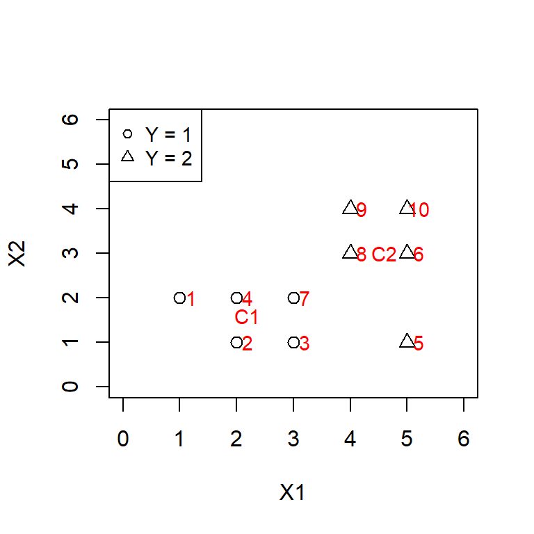

```r
library("dplyr")
K = 2
## Paso 0
C = matrix(NA, ncol = 2, nrow = K)

C[1, ] = c(2, 3)
C[2, ] = c(5, 3)

clusters = matrix(NA, ncol = 2, nrow = nrow(df))
clusters[, 1] = 1
clusters[, 2] = 2

i = 2
while(sum(clusters[, 1] == clusters[, 2]) != nrow(df)) {
## Paso 1
df = df %>%
  mutate(d_C1 = sqrt((X1 - C[1, 1])^2 + (X2 - C[1, 2])^2),
         d_C2 = sqrt((X1 - C[2, 1])^2 + (X2 - C[2, 2])^2),
         Y = ifelse(d_C1 < d_C2,
                    1,
                    2))
clusters[, 1] = df$Y
## Paso 2
centroides = df %>%
  group_by(Y) %>%
  summarise(C_x1 = mean(X1),
            C_x2 = mean(X2))
C[1, ] = c(centroides$C_x1[1], centroides$C_x2[1])
C[2, ] =  c(centroides$C_x1[2], centroides$C_x2[2])
df = df %>%
  mutate(d_C1 = sqrt((X1 - C[1, 1])^2 + (X2 - C[1, 2])^2),
         d_C2 = sqrt((X1 - C[2, 1])^2 + (X2 - C[2, 2])^2),
         Y = ifelse(d_C1 < d_C2,
                    1,
                    2))
clusters[, 2] = df$Y
i = i + 1
}

Y <- df$Y

plot(X1, X2, xlab = "X1", ylab = "X2", pch = as.integer(Y),
     xlim = c(0,6), ylim = c(0,6), cex = 1.2)
text(X1 + 0.2, X2, 1:length(X1), cex = 0.9, col = "red")
text(C[1, 1], C[1, 2], "C1", cex = 0.9, col = "red")
text(C[2, 1], C[2, 2], "C2", cex = 0.9, col = "red")
legend('topleft', legend = c('Y = 1','Y = 2'), pch = 1:2, cex = 0.9)
```

**¿Cómo comparar distintas soluciones?**

- Para comparar las soluciones podemos utilizar diversas medidas.
- Por ejemplo podíamos usar la función de costo $J$ (con distancias Euclídeas).

```r
## función costo J(y)
J <- function(df, C) {
  J= df %>%
    group_by(Y) %>%
    summarise(d = ifelse(Y ==1,
                         sqrt((X1 - C[1, 1])^2 + (X2 - C[1, 2])^2),
                         sqrt((X1 - C[2, 1])^2 + (X2 - C[2, 2])^2))) %>%
    ungroup
  return(sum(J$d))
}
```

- Para la solución $C_1 = (2.666667, 1.5)$ y $C_2 = (4.5, 3.5))$ ($sol1$):

```r
C = matrix(c(2.666667, 1.5,
             4.5, 3.5), nrow = 2, ncol =2, byrow = TRUE)
df = df %>%
  mutate(d_C1 = sqrt((X1 - C[1, 1])^2 + (X2 - C[1, 2])^2),
         d_C2 = sqrt((X1 - C[2, 1])^2 + (X2 - C[2, 2])^2),
         Y = ifelse(d_C1 < d_C2,
                    1,
                    2))
J(df, C)
```

```
[1] 9.823299
```

$J(y_{sol1})= 9.823299$.

- Para la solución $C_1=(2.2 ,1.6)$ y $C_2=( 4.6, 3.0)$ ($sol2$):

```r
C = matrix(c(2.2, 1.6,
             4.6, 3.0), nrow = 2, ncol =2, byrow = TRUE)
df = df %>%
  mutate(d_C1 = sqrt((X1 - C[1, 1])^2 + (X2 - C[1, 2])^2),
         d_C2 = sqrt((X1 - C[2, 1])^2 + (X2 - C[2, 2])^2),
         Y = ifelse(d_C1 < d_C2,
                    1,
                    2))
J(df, C)
```

```
[1] 9.521839
```

$J(y_{sol2})=9.521839$.

- Y para $J^*$ (con distancias Euclídeas al cuadrado),

```r
## función costo J^*(y)
J2 <- function(df, C) {
  J= df %>%
    group_by(Y) %>%
    summarise(d = ifelse(Y ==1,
                         (X1 - C[1, 1])^2 + (X2 - C[1, 2])^2,
                         (X1 - C[2, 1])^2 + (X2 - C[2, 2])^2)) %>%
    ungroup
  return(sum(J$d))
}
```

- Para la solución $C_1 = (2.666667, 1.5)$ y $C_2 = (4.500000, 3.5))$ ($sol1$):

```r
C = matrix(c(2.666667, 1.5,
             4.500000, 3.5), nrow = 2, ncol =2, byrow = TRUE)
df = df %>%
  mutate(d_C1 = sqrt((X1 - C[1, 1])^2 + (X2 - C[1, 2])^2),
         d_C2 = sqrt((X1 - C[2, 1])^2 + (X2 - C[2, 2])^2),
         Y = ifelse(d_C1 < d_C2,
                    1,
                    2))
J2(df, C)
```

```
[1] 12.83333
```

$J^*(y_{sol1})= 12.83333.$

- Para la solución $C_1=(2.2 ,1.6)$ y $C_2=( 4.6, 3.0)$ ($sol2$):

```r
C = matrix(c(2.2, 1.6,
             4.6, 3.0), nrow = 2, ncol =2, byrow = TRUE)
df = df %>%
  mutate(d_C1 = sqrt((X1 - C[1, 1])^2 + (X2 - C[1, 2])^2),
         d_C2 = sqrt((X1 - C[2, 1])^2 + (X2 - C[2, 2])^2),
         Y = ifelse(d_C1 < d_C2,
                    1,
                    2))
J2(df, C)
```

```
[1] 11.2
```

$J^*(y_{sol2})= 11.2$.

- En ambos casos la solución segunda parece dar mejores resultados:
  $$J(y_{sol1})= 9.823299 > J(y_{sol2})=9.521839,$$
  $$J^*
  (y_{sol1})= 12.83333> J^*(y_{sol2})=11.2.$$

**`K-means` se puede ejecutar de forma automática en `R`**

- El algoritmo `K-means` se puede ejecutar de forma automática en `R` con el comando `Kmeans`.
- Por defecto, usa el algoritmo de Hartigan and Wong (1979).
- Para ejecutarlo en este ejemplo:

```r
X1 <- c(1, 2, 3, 2, 5, 5, 3, 4, 4, 5)
X2 <- c(2, 1, 1, 2, 1, 3, 2, 3, 4, 4)
d <- data.frame(X1, X2)
CA <- kmeans(d, 2)
CA$centers
```

```
   X1  X2
1 4.6 3.0
2 2.2 1.6
```

- Los grupos coinciden con los obtenidos en la segunda solución anterior (óptima).
- También se pueden guardar

```r
CA1 <- CA$centers[1,]
CA2 <- CA$centers[2,]
```

- Los grupos se obtienen con

```r
CA$cluster
```

```
 [1] 2 2 2 2 1 1 2 1 1 1
```

- La solución coincide con la representada en la gráfica.
- Las sumas de las distancias al cuadrado en los grupos se obtienen con

```r
CA$withinss
```

```
[1] 7.2 4.0
```

obteniendo $7.2 +4.0=11.2$ (como antes).

- El comando

```r
CA$totss
```

```
[1] 30.5
```

proporciona la suma de las distancias al cuadrado sin grupos (o con un único grupo) obteniéndose $30.5$.

- Si se calcula directamente,

```r
centroides = df %>%
  summarise(C_x1 = mean(X1),
            C_x2 = mean(X2))
C[1, ] = c(centroides$C_x1[1], centroides$C_x2[1])
df = df %>%
  mutate(d = (X1 - C[1, 1])^2 + (X2 - C[1, 2])^2)
sum(df$d)
```

```
[1] 30.5
```

- Por lo que al agruparlos se ha producido una disminución del
  $$1-\frac{11.2}{30.5}=0.6327869$$
  por uno, es decir, con dos grupos la `variabilidad` se reduce un $63.28\%$.
- Individuos agrupados con `Kmeans` en 2 grupos:

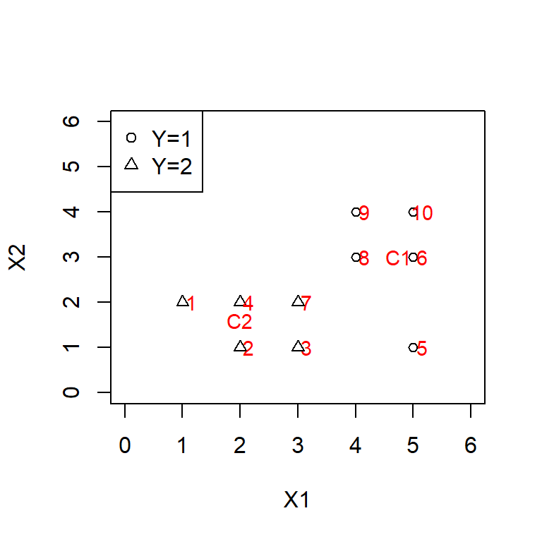

```r
K <- 2
CA <- kmeans(d, K)
plot(X1, X2, xlab = "X1", ylab = "X2", pch = as.integer(CA$cluster),
     xlim = c(0, 6), ylim = c(0, 6), cex = 0.9)
legend('topleft', legend = c('Y=1', 'Y=2'), pch = 1:K, cex = 1)
text(CA$centers[1, 1] + 0.15, CA$centers[1, 2], 'C1', cex = 0.9, col = 'red')
text(CA$centers[2, 1] - 0.20, CA$centers[2, 2], 'C2', cex = 0.9, col = 'red')
text(X1 + 0.15, X2, 1:length(X1), cex = 0.9, col = 'red')
```

- Individuos agrupados con `Kmeans` en 3 grupos (hay un grupo que tiene un único dato, por lo tanto, será su centroide):

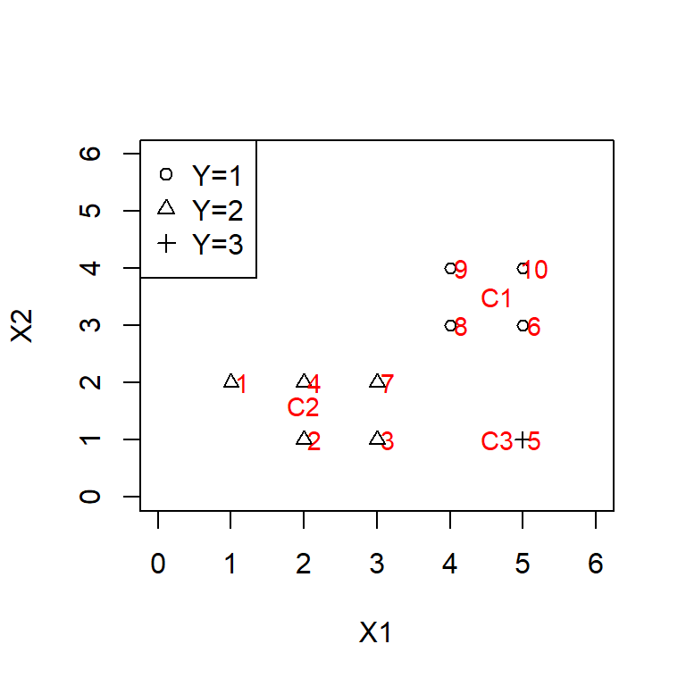

```r
K <- 3
CA <- kmeans(d, K)
plot(X1, X2, xlab = "X1", ylab = "X2", pch = as.integer(CA$cluster),
     xlim = c(0, 6), ylim = c(0, 6), cex = 0.9)
legend('topleft', legend = c('Y=1', 'Y=2', 'Y=3'), pch = 1:K, cex = 1)
text(CA$centers[1, 1] + 0.15, CA$centers[1, 2], 'C1', cex = 0.9, col = 'red')
text(CA$centers[2, 1] - 0.20, CA$centers[2, 2], 'C2', cex = 0.9, col = 'red')
text(CA$centers[3, 1] - 0.35, CA$centers[3, 2], 'C3', cex = 0.9, col = 'red')
text(X1 + 0.15, X2, 1:length(X1), cex = 0.9, col = 'red')
```

- Al ejecutar este comando pueden aparecer otras soluciones porque las `soluciones dependen de los valores iniciales`.
- La función `kmeans` permite ejecutar el algoritmo con diferentes valores de partida (argumento `nstart`) y proporcionar la mejor de esas soluciones.

```r
CA <- kmeans(d, 3, nstart = 10)
```

- Con tres grupos la variabilidad se reduce en un 80.3 %.

```r
CA = kmeans(d, 3, nstart = 10)
1- (sum(CA$withinss)/CA$totss)
```

```
[1] 0.8032787
```

## Método jerárquico

**Índice de similaridad**

- En este caso no fijamos de antemano un número de grupos.
- Lo que haremos es, dada una distancia, definir un `índice de similaridad entre dos observaciones` con
  $$I(\mathbf x^{(i)}, \mathbf x^{(j)})=1-\frac{d(\mathbf x^{(i)},\mathbf x^{(j)})}{\displaystyle \max_{r,s} d(\mathbf x^{(r)},\mathbf x^{(s)})}\in[0,1].$$
- Se puede dar una definición análoga para grupos.
- La idea es establecer clasificaciones calculando los índices de similitud (o distancias) que se van obteniendo.
- Finalmente, dependiendo del índice de similitud elegido, obtendremos un número determinado de grupos (uniendo los que tienen similitud menor que ese índice).

**Algoritmos**

- Consideraremos dos algoritmos.
- En el primero `partiremos de` $n$ `grupos formados por un individuo cada uno`.
  - En el primer paso uniremos las dos observaciones más cercanas (distancia mínima) que serán las que tengan un índice de similitud mayor.
  - Recalculamos las distancias para estos grupos y unimos los dos grupos más cercanos, continuamos así hasta conseguir un único grupo.
- En el segundo, procederemos de forma inversa, `partiremos de un único grupo` formado por todas las observaciones.
  - En un primer paso separaremos en dos de forma que las distancias entre estos dos grupos sea máxima (o las distancias a esos dos grupos de sus individuos sea mínima).
  - En el siguiente paso formaremos un tercer grupo tomando individuos de los grupos $1$ y $2$ con un criterio similar.
  - Procederemos así hasta conseguir $n$ grupos.
- Claramente, este método es más lento que el anterior.

**Un ejemplo sencillo**

- Para ver un ejemplo analizaremos los datos del ejemplo anterior usando el primer método.
- En primer lugar calculamos las distancias Euclídeas entre todos los individuos:

```r
n <- length(X1)
D <- matrix(NA, n, n)
for (i in 1:n) {
  for (j in 1:n) {
    D[i, j] <- dE(d[i, ], d[j, ])
    }
}
```

$$\scriptsize
\begin{array}{c|cccccccccc}
D & O_1 & O_2 & O_3 & O_4 & O_5 & O_6 & O_7 & O_8 & O_9 & O_{10}\\
\hline
O_1 & 0 &1.41&2.24& {\bf 1} &4.12 &4.12&2& 3.16& 3.61& {\bf 4.47}\\
O_2 &1.41 &0&1 &1& 3& 3.61&1.41& 2.83& 3.61 &4.24\\
O_3 & 2.24&1& 0& 1.41& 2& 2.83&1& 2.24& 3.16& 3.61\\
O_4 &1&1&1.41&0& 3.16&3.16&1&2.24&2.83&3.61\\
O_5 &4.12&3&2& 3.16& 0& 2&2.24&2.24&3.16& 3\\
O_6 &4.12&3.61&2.83&3.16&2&0&2.24& 1&1.41&1\\
O_7 &2&1.41& 1& 1&2.24&2.24&0&1.41&2.24&2.83\\
O_8 &3.16&2.83&2.24&2.24 &2.24 &1&1.41& 0&1&1.41\\
O_9 &3.61&3.61&3.16&2.83&3.16&1.41&2.24&1&0&1\\
O_{10} &{\bf 4.47}&4.24& 3.61&3.61&3&1&2.83&1.41&1& 0\\
\hline
\end{array}$$

- Observamos que el máximo se alcanza en $D_{1,10}=4.47$ y el mínimo eliminando los ceros es $1$ y se alcanza en varios puntos (esto se debe a que los puntos son discretos).
- El primero que detecta el programa es $D_{1,4}=1$ por lo que será el primer grupo $G_1=\{1,4\}$.
- El índice de similaridad será
  $$I(\mathbf x^{(1)},\mathbf x^{(4)})=1-\frac{d(\mathbf x^{(1)}, \mathbf x^{(4)})}{\displaystyle \max_{r,s} d(\mathbf x^{(r)}, \mathbf x^{(s)})}=1-\frac 1{4.472136
  }=0.7763932.$$
- El siguiente paso dependerá de la distancia entre grupos elegida.
- Si queremos mantener esas distancias y detectar esos empates debemos elegir la distancia del `vecino más próximo` ($D_2$).
- Todas las demás nos darán valores mayores. Con esta distancia (tras varias iteraciones) uniríamos todos los puntos que están a distancia $1$ de alguno del grupo obteniendo:
  $$G_1=\{1,2,3,4,7\},\ G_2=\{5\}, G_3=\{6,8,9,10\}.$$
- La matriz de distancias $D_2$ para estos tres grupos será
  $$\begin{array}{|c|ccc|}
  \hline
  D_2 & G_1 & G_2 & G_3\\
  \hline
  G_1 &0 & 2 & {\bf 1.41}\\
  G_2 &2 & 0 & 2\\
  G_3 & {\bf 1.41} & 2 & 0\\
  \hline
  \end{array}$$
- El mínimo se alcanza en $d(G_1,G_3)=d(\mathbf x^{(7)},\mathbf x^{(8)} )=1.41$.
- Por lo que en el segundo paso uniríamos los grupos $G_1$ y $G_3$ que tendrán un índice de similaridad
  $$I(\mathbf x^{(7)},\mathbf x^{(8)})=1-\frac{d(\mathbf x^{(7)},\mathbf x^{(8)})}{\displaystyle \max_{r,s} d(\mathbf x^{(r)},\mathbf x^{(s)})}=1-\frac {1.41}{4.472136
  }=0.6847144.$$
- En el último paso uniríamos el grupo $G_2$ con $G_1\cup G_3$ a distancia $2$ y similaridad
  $$I(\mathbf x^{(3)}, \mathbf x^{(5)})=1-\frac{d(\mathbf x^{(3)},\mathbf x^{(5)})}{\displaystyle \max_{r,s} d(\mathbf x^{(r)}, \mathbf x^{(s)})}=1-\frac {2}{4.472136
  }=0.5527864.$$
- El dendograma debe mostrar estas uniones usando las distancias o los índices de similaridad.
- Con otras distancias y/o usando el segundo método (que parte de un único grupo que se separa en dos) podemos obtener resultados diferentes.
- También observamos que los resultados no tienen por qué coincidir con los obtenidos con el algoritmo $K$-medias.
- La elección de un método u otro dependerá de los datos que tengamos y del problema que se quiera resolver (`costo`).
  - Por ejemplo, si lo que queremos es agrupar a los usuarios para ser atendidos por centros deberemos usar distancias basadas en centroides que representarán dónde se situarán (aproximadamente) esos centros.
  - Por contra, si lo que queremos es simplemente clasificar empresas o países según sus características, estos centroides no serán tan importantes.

**¿Cómo realizar este agrupamiento de forma automática en `R`?**

- Podemos usar la función `hclust`.
- En primer lugar calcularemos las distancias con

```r
D <- dist(d, method = 'euclidean')
```

representadas en forma de vector.

- Para visualizarlas en forma de matriz usaremos `as.matrix(D)[1:10, 1:10]`.
- Ahora, para hacer un CA utilizamos la instrucción

```r
CA2 <- hclust(D, method = 'complete')
```

- Hemos usado el método de agrupación `complete` que usa la distancia del vecino más lejano (es el que usa `R` por defecto).
- Otras opciones son:
  - `single`: vecino más cercano,
  - `average`: media de todas las distancias entre todas las parejas de puntos de los dos grupos y
  - `centroid`: distancia entre los centroides.
- Para $K=4$ grupos

```r
grupos <- cutree(CA2, k = 4)
```

obtendremos los grupos:

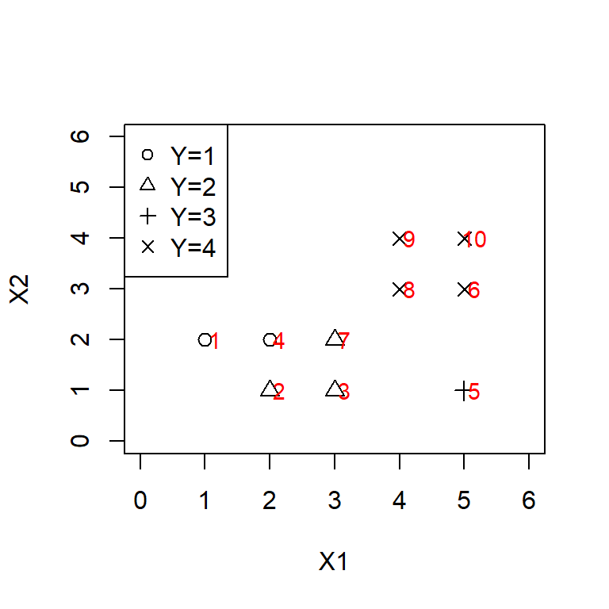

```r
plot(X1, X2, pch = as.integer(grupos),
     xlim = c(0, 6), ylim = c(0, 6), cex = 1.2)
legend('topleft', legend = c('Y=1', 'Y=2', 'Y=3', 'Y=4'),
       pch = 1:4, cex = 1)
text(X1 + 0.15, X2, 1:n, cex = 0.9, col = 'red')
```

- Representación del `dendograma`.
- La línea roja en el dendograma representa la distancia que nos da $4$ grupos.

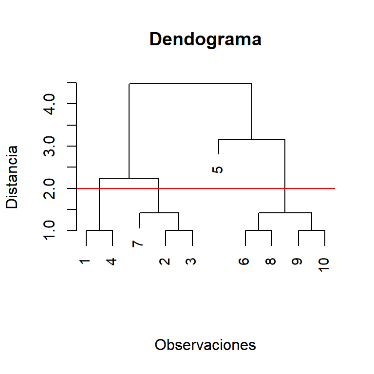

```r
plot(CA2, cex = 0.9, main = 'Dendograma',
     ylab = 'Distancia', xlab = 'Observaciones', sub = '')
abline(h = 2, col = 'red')
```

- En el dendograma primero se unen los puntos que están a menor distancia (en este caso era distancia 1) y, posteriormente se calculan las distancias entre grupos usando la distancia al vecino más lejano ($D_3$).
- Por ejemplo, la distancia de la observación $7$ al grupo $\{2,3\}$ es

```r
dE(d[7, ], d[2, ])
```

```
[1] 1.414214
```

es decir, $1.414214$.

- Lo mismo ocurre con la distancia entre los grupos $\{6,8\}$ y $\{9,10\}$. La distancia mayor es la de la observación $5$ al grupo $\{6,8,9,10\}$ obtenida con

```r
dE(d[5, ], d[9, ])
```

```
[1] 3.162278
```

y que vale $3.162278$.

[figure not shown]

Análisis Estadístico Multivariante, GCID